# IE6400 Foundations for Data Analytics Engineering

# Fall 2023

### Module 2: Regression and Prediction

#### Regression

Definition: Regression analysis is a statistical method used for modeling the relationship between a dependent variable and one or more independent variables. The goal of regression is to find the mathematical equation that describes the relationship between the dependent and independent variables.

Types:

- Linear Regression:
  - Simple Linear Regression: Models the relationship between a dependent variable and one independent variable using a linear equation.
  - Multiple Linear Regression: Involves two or more independent variables.
- Polynomial Regression: Uses a polynomial equation instead of a linear equation to model the relationship between variables.
- Logistic Regression: Used for binary classification problems, it models the probability that the dependent variable belongs to a particular category.

Applications:

- Predicting sales based on advertising spend.
- Estimating the relationship between rainfall and crop yield.
- Predicting house prices based on features like size and location.

#### Prediction

Definition: Prediction involves estimating the future value of a variable (or variables) based on historical data and analysis. It is often used in the context of machine learning, where algorithms are trained on historical data to make predictions or decisions without being explicitly programmed to perform the task.

Types:

- Classification: Predicting which category or class the new data will fall into based on the training data.
- Regression (in the context of prediction): Predicting a continuous value. Time Series Forecasting: Predicting future values based on previously observed values in time-series data.

Applications:

- Forecasting stock prices.
- Predicting weather conditions.
- Recommending products to customers based on past purchases.

#### Relationship Between Regression and Prediction:

In the context of machine learning and statistics, regression analysis is often used for prediction. Specifically, regression models can be used to predict the dependent variable based on new data for the independent variable(s). For example, a simple linear regression model could be used to predict a person's weight based on their height.

#### In summary:

- Regression is more about understanding the relationship between variables.
- Prediction is about estimating unknown values based on known values.

#### Linear Regression

Used to find Linear Relationship between dependent and one or more independent variables  
`Linear Regression` is a `Supervised Learning Algo` to solves Regression problems`where we try to predict a`Continuous Variable`

Linear Regression can be further classified into two types:

1. `Simple Linear Regression`
2. `Multiple Linear Regression`

#### 1. Simple Linear Regression (SLR)

It is the simplest model in machine learning. It models the linear relationship between the independent and dependent variables.

`This application of Linear Regression is based on the TV and Sales data`

- In data we have one `Independent or Input Variable` which represents `TV`, `denoted by X`
- In data we have one `Dependent or Output Variable` which represents `Sales`,`denoted by y`  
  I am trying to build a Linear Relationship between these variables. This linear relationship can be modelled by mathematical equation of the form:-

  ```
                 Y = β0  + β1X    -------------   (1)
  ```

In this equation:

- `X` is `Independent Variables`
- `Y` is `Dependent Variables`
- `β1` is `Coefficient for independent variable`
- `β0` is `Constant Term`
- `β0` and `β1` are called `Parameters of Model`

For simplicity, compare above equation with basic linear equation of form:-

```
               y = mx + c       -------------   (2)
```

- `m` = `β1` => `Slope` of line
- `c` = `β0` => `Intercept` of line

In this Simple Linear Regression Model, we are trying to fit a line which estimates Linear Relationship between X and Y  
So, the question of fitting reduces to estimating the parameters of the model β0 and β1

#### Ordinary Least Square Method

A scatter plot is a type of data display that shows the relationship between two numerical variables. Each member of the dataset gets plotted as a point whose (x, y) coordinates relate to its values for the two variables1.

In linear regression, the goal is to find a line that best fits the scatter plot. This line is called the Regression Line. It helps us predict the value of a target variable for any given feature variable.

To find the best fit line, we can define an error function for any line. The error function measures how well the line fits the data. The goal is to find a line that minimizes the error function. Such an error function is also called a Cost Function.

By below chart you might understand more clearly

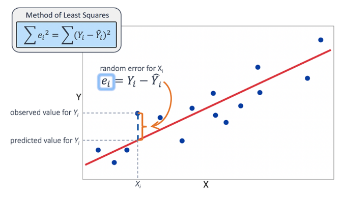

#### Variables

- Independent
- Dependent

**`1. Independent variable`**  
Independent variable is also called Input or Feature or Predictor Variable and is denoted by X

It can be denoted it as:- **`Independent or Input variable (X) = Feature variable = Predictor variable`**

**`2. Dependent variable`**  
Dependent variable is also called Output or Target or Response Variable and is denoted by y.

It can be denoted it as:- **`Dependent or Output variable (y) = Target variable = Response variable`**

#### Reshaping X and y

- Since we are working with only one feature variable, so we need to reshape using Numpy reshape() method

`Example`: If you have an array of shape (3,2) then reshaping it with (-1, 1), then the array will get reshaped in such a way that the resulting array has only 1 column and this is only possible by having 6 rows, hence, (6,1) Here it was required to make the data in proper dimentions to perform operations further.

And reshaping helps in maintaining the dimentionality consistant

#### Difference in dimensions of X and y after reshaping

It is essential in this case because getting the feature and target variable right is an important precursor to model building.

#### Performing Simple Linear Regression

Linear Regression Equation:

$y = c + m_1x_1 + m_2x_2 + ... + m_nx_n$

- $y$ is the response
- $c$ is the intercept
- $m_1$ is the coefficient for the first feature
- $m_n$ is the coefficient for the nth feature

In our case:

$y = c + m_1 \times TV$

$m$ = **model coefficients** or **model parameters**

#### Mechanics of the model

- It is good to understand the generic structure of modeling using scikit-learn library
- Broad steps to build any model can be divided as follows:
  - Split dataset into two sets – training set and test set
  - Instantiate regressor lm and fit it on training set with fit method
  - In above step model learned relationships between training data (X_train, y_train)
- Now model is ready to make predictions on test data (X_test)
- So predict on test data using predict method

#### Train test split

- Split dataset into two sets namely - train set and test set
- Model learn relationships from training data and predict on test data

`random_state` is a parameter used in machine learning models to control the randomness of the data splitting process. It is used to ensure that the results are reproducible. If you set the `random_state` parameter to an integer, the randomization will always be the same, allowing you to get the same results every time you run the model¹.

`test_size` is another parameter used in machine learning models, specifically when splitting the data into training and testing sets. It represents the proportion of the dataset that should be included in the test set. For example, if you set `test_size` to 0.3, 30% of the data will be used for testing and 70% will be used for training³.

#### Model slope and intercept term

- `Model slope is given by lm.coef_`
- `Model intercept is given by lm.intercept_.`

`For example`:  
if estimated model slope and intercept values are 1.60509347 and -11.16003616

So, equation of fitted regression line will be:-

`y = 1.60509347 * x - 11.16003616`

# `Model Performance`

### `Regression Metrics`

To Evaluate Model Performance

For Regression Problems there are two ways to Compute Model Performance

1. **`RMSE (Root Mean Square Error)`**
   - RMSE is standard deviation of residuals, it gives us standard deviation of unexplained variance by model `calculated by taking square root of Mean Squared Error`
   - RMSE is an absolute measure of fit, gives us how spread residuals are, given by standard deviation of the residuals
   - `More concentrated data is around regression line, lower the residuals and hence lower standard deviation of residuals`
   - It results in lower values of RMSE as `lower values of RMSE indicate better fit of data`

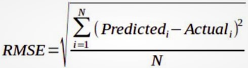

1. **`R-Squared Value`**
   - `(R2) Correlation` explains strength of relationship between an independent and dependent variable
   - `R-square` explains to what extent variance of one variable explains variance of second variable. It may also be known as the coefficient of determination
   - `If R2 of a model is 0.50, then approximately half of observed variation can be explained by model's inputs`
   - `In general higher R2 Score value better model fits data`
   - `Its value ranges from 0 to 1`
   - So we want its value to be as close to 1
   - `Its value can become negative if our model is wrong`

**`R2` = 1 - (sum squared regression error`SS regression` / `SS total`sum squared total error)**

**sum squared total error`SS total` = sum over all data points(each data point`yi`-`ybar`mean value)`^2`**

**sum squared regression error`SS regression` = sum over all data points (each datapoint`yi` - `y regression`regression value)`^2`**

#### Residual analysis

- Linear regression model may not represent data appropriately, model may be a poor fit to data
  - So we should validate our model by defining and examining residual plots
  - `Difference between observed value of dependent variable (y) and predicted value (ŷi) is called residual and is denoted by e or error`
  - Scatter-plot of these residuals is called residual plot

If data points in a residual plot are randomly dispersed around horizontal axis and an approximate zero residual mean, a linear regression model may be appropriate for data. Otherwise a non-linear model may be more appropriate

#### Checking for Overfitting and Underfitting

**`Underfitting:`**

- Model underfitts training data when model performs poorly on training data
- This is because model is unable to capture relationship between input examples (often called X) and target values (often called Y)

**`Overfitting:`**

- Model overfitts training data when you see that model performs well on training data but does not perform well on evaluation data
- This is because model is memorizing data it has seen and is unable to generalize to unseen examples

#### Simple Linear Regression - Model Assumptions

The Linear Regression Model is based on several assumptions which are listed below:-

1. `Linear relationship`
2. `Multivariate normality`
3. `No or little multicollinearity`
4. `No auto-correlation`
5. `Homoscedasticity`
1. `Linear relationship` The relationship between response and feature variables should be linear. This linear relationship assumption can be tested by plotting a scatter-plot between response and feature variables.
2. `Multivariate normality` The linear regression model requires all variables to be multivariate normal. A multivariate normal distribution means a vector in multiple normally distributed variables, where any linear combination of the variables is also normally distributed.
3. `No or little multicollinearity` It is assumed that there is little or no multicollinearity in the data. Multicollinearity occurs when the features (or independent variables) are highly correlated.
4. `No auto-correlation` Also, it is assumed that there is little or no auto-correlation in the data. Autocorrelation occurs when the residual errors are not independent from each other.
5. `Homoscedasticity` Homoscedasticity describes a situation in which the error term (that is, the noise in the model) is the same across all values of the independent variables. It means the residuals are same across the regression line. It can be checked by looking at scatter plot.

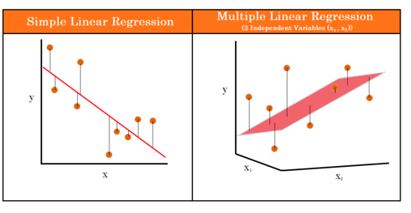

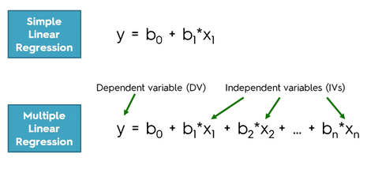

#### Logistic Regression

Logistic Regression is a Machine Learning classification algorithm that is used to predict the probability of a categorical dependent variable. In logistic regression, the dependent variable is a binary variable that contains data coded as 1 (yes, success, etc.) or 0 (no, failure, etc.). In other words, the logistic regression model predicts P(Y=1) as a function of X.

#### Gauss-Markov

The Gauss-Markov theorem is a fundamental result in econometrics and statistics that pertains to the properties of the ordinary least squares (OLS) estimator in linear regression analysis. The theorem establishes the conditions under which the OLS estimator is the Best Linear Unbiased Estimator (BLUE). Let's break down the key concepts and properties associated with the Gauss-Markov theorem:

**1. Gauss-Markov Theorem:**

The Gauss-Markov theorem asserts that under certain conditions, the OLS estimator of the coefficients in a linear regression model is the Best Linear Unbiased Estimator (BLUE). This means that among all linear unbiased estimators, the OLS estimator has the smallest variance, making it the most efficient and precise estimator of the true population parameters.

**2. Properties of Estimators:**

- **Unbiasedness:** An estimator is unbiased if, on average, it provides estimates that are equal to the true population parameters. The OLS estimator is unbiased when the Gauss-Markov assumptions are satisfied.
- **Efficiency:** Efficiency refers to how well an estimator utilizes the available information in the data. The OLS estimator is efficient because it has the minimum variance among all linear unbiased estimators when the Gauss-Markov assumptions are met.
- **Linearity:** The OLS estimator is a linear combination of the observed data, making it a straightforward and interpretable estimator.
- **Minimum Variance:** The key property emphasized by the Gauss-Markov theorem is the OLS estimator's ability to minimize the variance of the estimation errors (residuals) among all linear unbiased estimators.

**3. Assumptions of the Gauss-Markov Theorem:**

The Gauss-Markov theorem relies on several key assumptions:

- Linearity: The relationship between the dependent variable and the independent variables is linear.
- Random Sampling: The data should be collected using random sampling techniques to ensure that the sample is representative of the population.
- No Perfect Collinearity: There should be no perfect linear relationship among the independent variables.
- Zero Conditional Mean: The error term should have a mean of zero conditional on the values of the independent variables.
- Homoscedasticity: The variance of the error term should be constant across all levels of the independent variables.
- No Autocorrelation: There should be no serial correlation or autocorrelation in the error term.
- Normality: While not crucial for the Gauss-Markov theorem, normality of the error term simplifies hypothesis testing and construction of confidence intervals.

In summary, the Gauss-Markov theorem establishes that when the assumptions are met, the OLS estimator is the Best Linear Unbiased Estimator, offering unbiased parameter estimates with the smallest possible variance among all linear unbiased estimators. However, it's essential to recognize that these assumptions may not always hold in practice, and violation of these assumptions can affect the validity of OLS results. Therefore, researchers often conduct diagnostic tests to assess the validity of these assumptions and make necessary adjustments or consider alternative estimation methods when needed.

#### Polynomial Regression

What is Polynomial Regression: Polynomial regression is a statistical method used to model curvilinear relationships between a dependent variable and one or more independent variables. One way to identify the need for polynomial regression is to inspect the residuals of a linear regression model. If the residuals show a curved pattern, then a polynomial model may be a better fit. Another reason to use polynomial regression is that the independent variables in a multiple linear regression model are assumed to be independent. However, this assumption is not satisfied in polynomial regression, because the independent variables are related to each other through the polynomial terms.

Polynomial regression is a type of regression analysis that models the relationship between a dependent variable and one or more independent variables using a polynomial function. A polynomial function is a function of the form:

$f(x)=ax^n+bx^n−1+...+c$

where a, b, ..., c are constants and n is the degree of the polynomial.

Applications of polynomial regression :

*Predict the spread of diseases.

*Determine the optimal dosage of a drug.

*Price products.

*Optimize manufacturing processes.

*Analyze financial data.